# Public Support for Sports Betting Restrictions: Analysis Code

This document reproduces every analysis in the manuscript, in the order the results appear. Section headings name the manuscript table each chunk produces. Sections marked supplementary are not reported in the manuscript. The data file (attitudes_osf.csv) has identifying fields removed and participant IDs replaced with study codes.

## Data Analysis

### Summary Statistics

#### Demographics (Table 2)

Age

| Mean | SD | Min | Median | Max |
| --- | --- | --- | --- | --- |
| 45.44 | 15.66 | 18 | 46 | 80 |

Gender

| Level | n | Percent |
| --- | --- | --- |
| Male | 223 | 50.11 |
| Female | 222 | 49.89 |

Race/Ethnicity

| Level | n | Percent |
| --- | --- | --- |
| White (Non-Hispanic) | 244 | 54.83 |
| White (Hispanic) | 66 | 14.83 |
| African American or Black | 60 | 13.48 |
| Non-White Hispanic | 23 | 5.17 |
| East Asian | 18 | 4.04 |
| Other | 18 | 4.04 |
| South Asian | 7 | 1.57 |
| Middle Eastern or North African | 4 | 0.90 |
| American Indian or Alaskan Native | 3 | 0.67 |
| Native Hawaiian or Other Pacific Islander | 2 | 0.45 |

Financial Wellbeing

| Level | n | Percent |
| --- | --- | --- |
| I have a little left over after basic needs | 112 | 25.17 |
| I am somewhat financially comfortable | 108 | 24.27 |
| I am financially comfortable | 91 | 20.45 |
| I can just meet basic needs | 77 | 17.30 |
| I struggle to meet basic needs | 31 | 6.97 |
| I am financially well-off | 22 | 4.94 |
| I cannot meet basic needs | 4 | 0.90 |

Education

| Level | n | Percent |
| --- | --- | --- |
| Bachelor’s or 4 year degree (ex. BA, BS) | 186 | 41.80 |
| Some college, no degree | 81 | 18.20 |
| Masters degree (ex. MA, MS, MBA) | 71 | 15.96 |
| High school graduate or equivalent (ex. GED) | 44 | 9.89 |
| Associate degree (ex. AA, AS) | 38 | 8.54 |
| Doctorate or Professional degree (eg. PhD, MD, JD, DDS, EdD) | 22 | 4.94 |
| Less than High School (no diploma) | 3 | 0.67 |

```
[1] "Median completion time: 6 minutes 23 seconds"
```

#### Sports Betting Habits

Days since last bet placed

| Mean | SD | Min | Median | Max |
| --- | --- | --- | --- | --- |
| 13.18 | 23.3 | 0 | 4 | 99 |

Number of bets placed in a typical week

| Mean | SD | Min | Median | Max |
| --- | --- | --- | --- | --- |
| 1.43 | 4.23 | 0 | 0.1 | 50 |

Average amount of $ placed on a bet

| Mean | SD | Min | Median | Max |
| --- | --- | --- | --- | --- |
| 33.42 | 85.8 | 0 | 10 | 1000 |

Year participant began sports betting

| Mean | SD | Min | Median | Max |
| --- | --- | --- | --- | --- |
| 2004.5 | 33.92 | 1900 | 2020 | 2028 |

Number of sports betting platforms used

| Mean | SD | Min | Median | Max |
| --- | --- | --- | --- | --- |
| 1.19 | 1.26 | 0 | 1 | 10 |

Most common type of bet placed

| Level | n | Percent |
| --- | --- | --- |
| Moneyline (betting which team will win outright) | 174 | 39.10 |
| I have never placed a sports bet | 109 | 24.49 |
| Spread (betting by how much a team will win or lose) | 66 | 14.83 |
| Over/Under final score | 40 | 8.99 |
| Bets on any individual player | 30 | 6.74 |
| Other types of bets | 26 | 5.84 |

Betting activity percentages reported in the text

| FewerThanOneBetPerWeek | EverPlacedBet |
| --- | --- |
| 67.64 | 75.51 |

#### Sports Engagement

Sports Engagement Sum Score

| Mean | SD | Min | Median | Max |
| --- | --- | --- | --- | --- |
| 19 | 12.06 | 0 | 17 | 60 |

Number of Leagues Followed

| Mean | SD | Min | Median | Max |
| --- | --- | --- | --- | --- |
| 8.71 | 4.43 | 0 | 9 | 15 |

#### Peer Influence

Percent Peers Bet

| Mean | SD | Min | Median | Max |
| --- | --- | --- | --- | --- |
| 23.62 | 22.26 | 0 | 20 | 100 |

Peer Approval Rating

| Mean | SD | Min | Median | Max |
| --- | --- | --- | --- | --- |
| 3.12 | 1.66 | 0 | 3 | 6 |

Peers Struggle With Gambling Addiction

| Level | n | Percent |
| --- | --- | --- |
| No | 352 | 79.1 |
| Yes | 93 | 20.9 |

Self Struggle With Gambling Addiction

| Level | n | Percent |
| --- | --- | --- |
| No | 399 | 89.66 |
| Yes | 46 | 10.34 |

#### Attitudes Toward Gambling

ATGS

| Mean | SD | Min | Median | Max |
| --- | --- | --- | --- | --- |
| 1.79 | 0.9 | 0 | 1.88 | 3.88 |

#### Betting Statements

Provides meaningful economic benefits

| Mean | SD | Min | Median | Max |
| --- | --- | --- | --- | --- |
| 2.26 | 1.21 | 0 | 3 | 4 |

Concern about potential negative consequences

| Mean | SD | Min | Median | Max |
| --- | --- | --- | --- | --- |
| 2.76 | 1.27 | 0 | 3 | 4 |

Sports betting advertisements are too frequent

| Mean | SD | Min | Median | Max |
| --- | --- | --- | --- | --- |
| 2.89 | 1.19 | 0 | 3 | 4 |

#### Responsibility Statements

Individual sports bettors

| Mean | SD | Min | Median | Max |
| --- | --- | --- | --- | --- |
| 2.59 | 1.13 | 0 | 3 | 4 |

Sports betting companies

| Mean | SD | Min | Median | Max |
| --- | --- | --- | --- | --- |
| 2.85 | 1.12 | 0 | 3 | 4 |

Government regulators

| Mean | SD | Min | Median | Max |
| --- | --- | --- | --- | --- |
| 2.49 | 1.24 | 0 | 3 | 4 |

Sports leagues and organizations

| Mean | SD | Min | Median | Max |
| --- | --- | --- | --- | --- |
| 2.28 | 1.26 | 0 | 2 | 4 |

Broadcasters and media platforms

| Mean | SD | Min | Median | Max |
| --- | --- | --- | --- | --- |
| 2.04 | 1.29 | 0 | 2 | 4 |

#### Bet Allowance

Each of the nine statements keeps the rating participants gave it, from 0 (strongly disagree) to 6 (strongly agree). Higher scores mean more agreement with that specific statement, so they are not on a shared permissiveness scale and are summarized separately.

Agreement with each bet allowance statement by league type

| Statement | LeagueType | n | Mean | SD | Min | Median | Max |
| --- | --- | --- | --- | --- | --- | --- | --- |
| No bets should be allowed | Youth | 445 | 4.57 | 1.85 | 0 | 5 | 6 |
|  | Amateur | 445 | 2.66 | 2.01 | 0 | 3 | 6 |
|  | Professional | 445 | 2.06 | 2.06 | 0 | 1 | 6 |
| Proposition bets should be banned | Youth | 445 | 4.67 | 1.72 | 0 | 5 | 6 |
|  | Amateur | 445 | 2.88 | 1.98 | 0 | 3 | 6 |
|  | Professional | 445 | 2.57 | 2.08 | 0 | 2 | 6 |
| All bets should be allowed | Youth | 445 | 1.40 | 1.87 | 0 | 1 | 6 |
|  | Amateur | 445 | 3.17 | 2.05 | 0 | 4 | 6 |
|  | Professional | 445 | 3.62 | 2.08 | 0 | 4 | 6 |

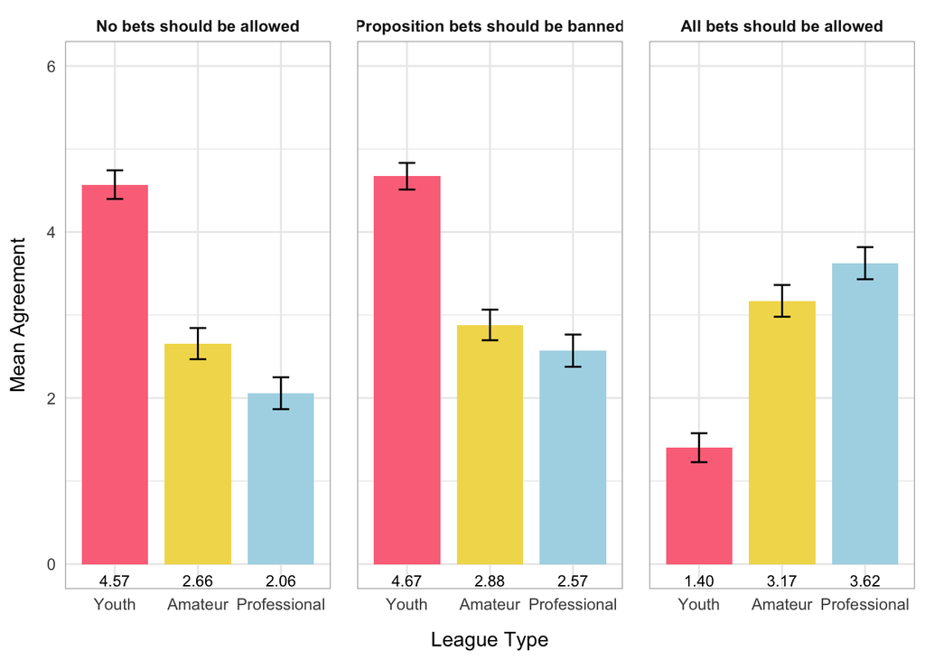

#### Skewness of Continuous Variables (Table 3)

Variables with absolute skewness above 1 are summarized with the median and interquartile range (IQR) and enter the correlations and models as log(x + 1). All others are summarized with the mean and standard deviation and enter the analyses untransformed.

Table 3 draft: summary of continuous variables with skewness

| Group | Label | n | Skew | SkewZ | Statistic | Value | Range |
| --- | --- | --- | --- | --- | --- | --- | --- |
| Sports betting habits | Bets placed per week | 445 | 7.83 | 67.63 | Median [IQR] | 0.10 [0.00, 1.00] | 0 to 50 |
|  | Typical wager amount ($) | 445 | 7.61 | 65.80 | Median [IQR] | 10.00 [0.00, 25.00] | 0 to 1000 |
|  | Number of sports betting platforms used | 445 | 1.54 | 13.28 | Median [IQR] | 1.00 [0.00, 2.00] | 0 to 10 |
| Sports engagement | Number of leagues followed (of 15) | 445 | -0.24 | -2.05 | M (SD) | 8.71 (4.43) | 0 to 15 |
| Peer influence | Percent of peers who regularly bet on sports | 445 | 0.86 | 7.45 | M (SD) | 23.62 (22.26) | 0 to 100 |
|  | Peer approval of sports betting (0 to 6) | 445 | -0.32 | -2.75 | M (SD) | 3.12 (1.66) | 0 to 6 |
| General gambling attitudes | ATGS-8 (0 to 4) | 445 | -0.12 | -1.04 | M (SD) | 1.79 (0.90) | 0 to 3.875 |
| Sports betting attitudes | Economic benefits (0 to 4) | 445 | -0.44 | -3.82 | M (SD) | 2.26 (1.21) | 0 to 4 |
|  | Concern about negative consequences (0 to 4) | 445 | -0.85 | -7.38 | M (SD) | 2.76 (1.27) | 0 to 4 |
|  | Advertisements are too frequent (0 to 4) | 445 | -0.87 | -7.55 | M (SD) | 2.89 (1.19) | 0 to 4 |
| Responsibility (0 to 4) | Sports betting companies | 445 | -0.96 | -8.29 | M (SD) | 2.85 (1.12) | 0 to 4 |
|  | Individual sports bettors | 445 | -0.49 | -4.26 | M (SD) | 2.59 (1.13) | 0 to 4 |
|  | Government regulators | 445 | -0.56 | -4.84 | M (SD) | 2.49 (1.24) | 0 to 4 |
|  | Sports leagues and organizations | 445 | -0.37 | -3.21 | M (SD) | 2.28 (1.26) | 0 to 4 |
|  | Broadcasters and media platforms | 445 | -0.12 | -1.06 | M (SD) | 2.04 (1.29) | 0 to 4 |

Note. Skew above 1 in absolute value is treated as substantial (Bulmer, 1979). The z values are skew divided by its standard error and are shown for reference only; at n = 445 almost any departure from symmetry is significant, so the absolute cutoff is used to decide.

Skewness of the nine bet allowance statements

| BetsAllowed | LeagueType | Skew | Statistic | Value |
| --- | --- | --- | --- | --- |
| No bets allowed | Youth | -1.24 | Median [IQR] | 5.00 [4.00, 6.00] |
| No bets allowed | Amateur | 0.22 | M (SD) | 2.66 (2.01) |
| No bets allowed | Professional | 0.73 | M (SD) | 2.06 (2.06) |
| No proposition bets allowed | Youth | -1.35 | Median [IQR] | 5.00 [4.00, 6.00] |
| No proposition bets allowed | Amateur | 0.06 | M (SD) | 2.88 (1.98) |
| No proposition bets allowed | Professional | 0.32 | M (SD) | 2.57 (2.08) |
| All bets allowed | Youth | 1.19 | Median [IQR] | 1.00 [0.00, 2.00] |
| All bets allowed | Amateur | -0.19 | M (SD) | 3.17 (2.05) |
| All bets allowed | Professional | -0.57 | M (SD) | 3.62 (2.08) |

### Correlations

#### Individual Difference Variables (Table A1)

Correlations among individual difference variables

|  | 1. | 2. | 3. | 4. | 5. | 6. | 7. | 8. | 9. | 10. | 11. | 12. | 13. |
| --- | --- | --- | --- | --- | --- | --- | --- | --- | --- | --- | --- | --- | --- |
| 1. Age | - |  |  |  |  |  |  |  |  |  |  |  |  |
| 2. Gender: Male | -.01 | - |  |  |  |  |  |  |  |  |  |  |  |
| 3. Education: Bachelor's or Higher | .07 | .04 | - |  |  |  |  |  |  |  |  |  |  |
| 4. Financial wellbeing | .08 | .09 | .31* | - |  |  |  |  |  |  |  |  |  |
| 5. White (Non-Hispanic) | .09 | .03 | -.06 | .10 | - |  |  |  |  |  |  |  |  |
| 6. ATGS | .11 | .08 | .02 | .13 | .03 | - |  |  |  |  |  |  |  |
| 7. Percent of peers who bet | -.11 | .00 | .09 | .13 | -.04 | .31* | - |  |  |  |  |  |  |
| 8. Peer approval | .00 | -.01 | .00 | .11 | -.01 | .55* | .52* | - |  |  |  |  |  |
| 9. Peer gambling struggle: Yes | -.09 | -.04 | .09 | .09 | -.09 | -.03 | .34* | .14 | - |  |  |  |  |
| 10. Self gambling struggle: Yes | -.08 | .00 | .11 | .08 | -.05 | .01 | .29* | .19* | .55* | - |  |  |  |
| 11. Bets per week (log) | -.11 | .22* | .11 | .14 | .00 | .36* | .40* | .34* | .17* | .22* | - |  |  |
| 12. Typical wager (log) | -.11 | .16* | .18* | .22* | -.07 | .33* | .41* | .38* | .21* | .21* | .38* | - |  |
| 13. Number of platforms (log) | -.12 | .19* | .08 | .19* | -.09 | .39* | .47* | .43* | .24* | .23* | .63* | .67* | - |
| 14. Sports engagement | -.04 | .19* | .19* | .24* | -.03 | .25* | .45* | .34* | .30* | .25* | .37* | .42* | .50* |

Note. Pearson r with pairwise deletion. * Holm-adjusted p < .05, corrected across the 91 correlations in this table.

#### Individual Differences with Bet Allowance Statements (Table A2, top)

Correlations between individual difference variables and the nine bet allowance statements

|  | No bets: Youth | No bets: Amateur | No bets: Professional | No props: Youth | No props: Amateur | No props: Professional | All bets: Youth | All bets: Amateur | All bets: Professional |
| --- | --- | --- | --- | --- | --- | --- | --- | --- | --- |
| Age | .09 | .02 | .05 | .06 | .03 | .14* | -.16* | -.08 | -.07 |
| Gender: Male | -.05 | .01 | -.04 | -.03 | .06 | .00 | .00 | -.01 | .05 |
| Education: Bachelor's or Higher | -.08 | -.03 | -.01 | -.07 | -.01 | .02 | .10 | .08 | .03 |
| Financial wellbeing | -.07 | -.07 | -.09 | -.08 | -.08 | -.10 | .10 | .08 | .12 |
| White (Non-Hispanic) | .03 | -.02 | -.06 | .01 | -.04 | -.07 | -.12* | -.04 | .00 |
| ATGS | -.32* | -.53* | -.50* | -.29* | -.52* | -.46* | .27* | .53* | .53* |
| Percent of peers who bet | -.27* | -.18* | -.19* | -.18* | -.13 | -.17* | .28* | .31* | .26* |
| Peer approval | -.21* | -.32* | -.39* | -.19* | -.30* | -.34* | .29* | .39* | .46* |
| Peer gambling struggle: Yes | -.09 | .11 | .01 | -.03 | .11 | .04 | .09 | -.02 | .04 |
| Self gambling struggle: Yes | -.10 | .02 | .04 | -.07 | .05 | .06 | .15* | .05 | .03 |
| Bets per week (log) | -.24* | -.23* | -.27* | -.18* | -.20* | -.25* | .24* | .28* | .31* |
| Typical wager (log) | -.19* | -.29* | -.26* | -.19* | -.23* | -.24* | .25* | .32* | .36* |
| Number of platforms (log) | -.27* | -.26* | -.33* | -.19* | -.22* | -.25* | .29* | .35* | .39* |
| Sports engagement | -.22* | -.13 | -.13* | -.19* | -.05 | -.10 | .27* | .21* | .21* |

Note. Pearson r with pairwise deletion. * Holm-adjusted p < .05, corrected within each column (14 correlations per column).

#### Individual Differences with Responsibility and Betting Statement Variables (Table A2, bottom)

Correlations between individual difference variables and the responsibility, economic benefits, negative consequences, and advertising variables

|  | Blame: individual bettors | Blame: betting companies | Blame: government | Blame: sports organizations | Blame: media | Economic benefits | Negative consequences | Frequent advertisements |
| --- | --- | --- | --- | --- | --- | --- | --- | --- |
| Age | .03 | -.09 | -.05 | .03 | -.09 | .02 | -.07 | -.07 |
| Gender: Male | .08 | .04 | .05 | .14* | .06 | .03 | .01 | .11 |
| Education: Bachelor's or Higher | .01 | .13 | .18* | .16* | .16* | .08 | .10 | .14* |
| Financial wellbeing | .13 | -.02 | .01 | -.01 | .01 | .11 | -.06 | -.05 |
| White (Non-Hispanic) | -.06 | -.04 | -.11 | -.05 | -.06 | -.03 | -.02 | .01 |
| ATGS | .05 | -.34* | -.36* | -.27* | -.31* | .55* | -.61* | -.51* |
| Percent of peers who bet | .07 | -.06 | .02 | .01 | .13* | .28* | -.04 | -.08 |
| Peer approval | .05 | -.21* | -.14* | -.13 | -.15* | .47* | -.30* | -.27* |
| Peer gambling struggle: Yes | .10 | .06 | .15* | .20* | .22* | .05 | .10 | .09 |
| Self gambling struggle: Yes | .05 | .05 | .13* | .11 | .17* | .07 | .06 | .05 |
| Bets per week (log) | .06 | -.05 | -.02 | .01 | .01 | .29* | -.14* | -.05 |
| Typical wager (log) | .07 | -.02 | .02 | .03 | .04 | .30* | -.14* | -.12 |
| Number of platforms (log) | .11 | -.02 | -.01 | .02 | .05 | .36* | -.12 | -.10 |
| Sports engagement | .10 | .02 | .13 | .12 | .12 | .30* | .02 | -.01 |

Note. Pearson r with pairwise deletion. * Holm-adjusted p < .05, corrected within each column (14 correlations per column).

#### Bet Allowance Statements (Table A3, top)

Correlations among the nine bet allowance statements

|  | 1. | 2. | 3. | 4. | 5. | 6. | 7. | 8. |
| --- | --- | --- | --- | --- | --- | --- | --- | --- |
| 1. No bets: Youth | - |  |  |  |  |  |  |  |
| 2. No bets: Amateur | .28* | - |  |  |  |  |  |  |
| 3. No bets: Professional | .24* | .49* | - |  |  |  |  |  |
| 4. No props: Youth | .72* | .29* | .22* | - |  |  |  |  |
| 5. No props: Amateur | .25* | .70* | .44* | .30* | - |  |  |  |
| 6. No props: Professional | .27* | .49* | .73* | .30* | .51* | - |  |  |
| 7. All bets: Youth | -.52* | -.24* | -.13* | -.51* | -.25* | -.20* | - |  |
| 8. All bets: Amateur | -.27* | -.63* | -.38* | -.27* | -.59* | -.41* | .39* | - |
| 9. All bets: Professional | -.27* | -.46* | -.72* | -.25* | -.44* | -.71* | .30* | .52* |

Note. Pearson r with pairwise deletion. * Holm-adjusted p < .05, corrected across the 36 correlations in this table.

#### Responsibility and Betting Statement Variables (Table A3, bottom)

Correlations among the responsibility, economic benefits, negative consequences, and advertising variables

|  | 1. | 2. | 3. | 4. | 5. | 6. | 7. |
| --- | --- | --- | --- | --- | --- | --- | --- |
| 1. Blame: individual bettors | - |  |  |  |  |  |  |
| 2. Blame: betting companies | .10 | - |  |  |  |  |  |
| 3. Blame: government | .01 | .61* | - |  |  |  |  |
| 4. Blame: sports organizations | .09 | .52* | .55* | - |  |  |  |
| 5. Blame: media | .07 | .54* | .58* | .64* | - |  |  |
| 6. Economic benefits | .11 | -.13 | -.10 | -.06 | -.15* | - |  |
| 7. Negative consequences | -.08 | .31* | .40* | .27* | .33* | -.29* | - |
| 8. Frequent advertisements | -.06 | .35* | .37* | .25* | .34* | -.28* | .59* |

Note. Pearson r with pairwise deletion. * Holm-adjusted p < .05, corrected across the 28 correlations in this table.

#### Bet Allowance Statements with Responsibility and Betting Statement Variables (supplementary)

Correlations between the nine bet allowance statements and the responsibility, economic benefits, negative consequences, and advertising variables

|  | Blame: individual bettors | Blame: betting companies | Blame: government | Blame: sports organizations | Blame: media | Economic benefits | Negative consequences | Frequent advertisements |
| --- | --- | --- | --- | --- | --- | --- | --- | --- |
| No bets: Youth | -.06 | .21* | .10 | .03 | .02 | -.24* | .33* | .25* |
| No bets: Amateur | -.07 | .28* | .35* | .30* | .27* | -.44* | .46* | .37* |
| No bets: Professional | -.08 | .17* | .26* | .25* | .23* | -.39* | .38* | .27* |
| No props: Youth | -.06 | .21* | .13* | .04 | .03 | -.17* | .37* | .26* |
| No props: Amateur | -.05 | .32* | .38* | .30* | .30* | -.33* | .46* | .41* |
| No props: Professional | -.07 | .25* | .28* | .32* | .31* | -.33* | .41* | .33* |
| All bets: Youth | .11 | -.13* | -.04 | -.03 | .02 | .22* | -.31* | -.22* |
| All bets: Amateur | .07 | -.26* | -.30* | -.28* | -.24* | .39* | -.41* | -.35* |
| All bets: Professional | .09 | -.23* | -.27* | -.26* | -.26* | .41* | -.42* | -.32* |

Note. Pearson r with pairwise deletion. * Holm-adjusted p < .05, corrected within each column (9 correlations per column).

### Agreement With Each Statement (Table 4)

Agreement is 4 to 6 on the 0 to 6 bet allowance scale and 3 to 4 on the 0 to 4 betting statement scale. Disagreement is 0 to 2 and 0 to 1, and neutral is the scale midpoint.

Table 4 (top): percent disagreeing, neutral, and agreeing with each bet allowance statement

| BetsAllowed | LeagueType | Disagree | Neutral | Agree | n |
| --- | --- | --- | --- | --- | --- |
| No bets allowed | Youth | 16.2 | 6.5 | 77.3 | 445 |
|  | Amateur | 49.9 | 13.7 | 36.4 | 445 |
|  | Professional | 65.2 | 9.4 | 25.4 | 445 |
| No proposition bets allowed | Youth | 12.6 | 8.5 | 78.9 | 445 |
|  | Amateur | 42.7 | 17.8 | 39.6 | 445 |
|  | Professional | 52.4 | 13.9 | 33.7 | 445 |
| All bets allowed | Youth | 76.6 | 5.2 | 18.2 | 445 |
|  | Amateur | 39.1 | 10.1 | 50.8 | 445 |
|  | Professional | 29.2 | 9.7 | 61.1 | 445 |

Table 4 (bottom): percent disagreeing, neutral, and agreeing with each betting statement

| Statement | Disagree | Neutral | Agree | n |
| --- | --- | --- | --- | --- |
| Economic benefits | 27.0 | 22.0 | 51.0 | 445 |
| Negative consequences | 20.7 | 9.2 | 70.1 | 445 |
| Frequent advertisements | 15.7 | 14.8 | 69.4 | 445 |

### Bet Allowance Models

Each bet allowance statement is modeled separately, so the three models below are independent of one another. Within each model every participant contributes three observations, one per league, so a random intercept for participant accounts for the repeated measures. League type is contrast coded so each contrast sums to zero and its absolute values sum to one. C1 (AdultVsYouth) compares amateur and professional leagues against youth leagues (youth = -0.50, amateur = 0.25, professional = 0.25), and C2 (ProfessionalVsAmateur) compares professional against amateur leagues (youth = 0, amateur = -0.50, professional = 0.50). All other predictors are measured once per participant. Betting frequency, typical wager, and number of platforms enter as log(x + 1).

#### Models (Table 5)

|  | No bets allowed |  |  | No proposition bets allowed |  |  | All bets allowed |  |  |
| --- | --- | --- | --- | --- | --- | --- | --- | --- | --- |
| Predictors | Estimates | CI | p | Estimates | CI | p | Estimates | CI | p |
| (Intercept) | 2.90 | 2.17 – 3.62 | **<0.001** | 2.28 | 1.52 – 3.03 | **<0.001** | 3.02 | 2.27 – 3.76 | **<0.001** |
| LeagueTypeAdultVsYouth | -2.95 | -3.20 – -2.71 | **<0.001** | -2.59 | -2.83 – -2.36 | **<0.001** | 2.66 | 2.43 – 2.90 | **<0.001** |
| LeagueTypeProfessionalVsAmateur | -0.60 | -0.81 – -0.39 | **<0.001** | -0.31 | -0.51 – -0.11 | **0.003** | 0.45 | 0.25 – 0.66 | **<0.001** |
| Age10 | 0.09 | 0.02 – 0.16 | **0.008** | 0.14 | 0.07 – 0.21 | **<0.001** | -0.14 | -0.21 – -0.07 | **<0.001** |
| Gender [Male] | 0.03 | -0.19 – 0.24 | 0.793 | 0.17 | -0.05 – 0.39 | 0.136 | -0.11 | -0.33 – 0.11 | 0.328 |
| EducationBinary [Bachelor's or Higher] | -0.25 | -0.47 – -0.02 | **0.035** | -0.23 | -0.47 – 0.00 | 0.054 | 0.35 | 0.12 – 0.59 | **0.003** |
| FinancialNum | 0.03 | -0.05 – 0.12 | 0.399 | -0.01 | -0.09 – 0.07 | 0.831 | -0.02 | -0.10 – 0.06 | 0.615 |
| RaceBinary | -0.11 | -0.31 – 0.10 | 0.310 | -0.16 | -0.38 – 0.05 | 0.131 | -0.12 | -0.33 – 0.09 | 0.254 |
| ATGS mean | -0.30 | -0.48 – -0.11 | **0.002** | -0.28 | -0.47 – -0.09 | **0.004** | 0.23 | 0.04 – 0.42 | **0.020** |
| PeerPercent10 | -0.04 | -0.10 – 0.02 | 0.200 | -0.01 | -0.07 – 0.05 | 0.768 | 0.05 | -0.01 – 0.11 | 0.131 |
| PeerApproveNum | -0.00 | -0.09 – 0.08 | 0.970 | -0.01 | -0.10 – 0.07 | 0.751 | 0.11 | 0.02 – 0.19 | **0.015** |
| PeerStruggle [Yes] | 0.13 | -0.18 – 0.44 | 0.424 | 0.17 | -0.15 – 0.49 | 0.303 | -0.19 | -0.51 – 0.13 | 0.234 |
| SelfStruggle [Yes] | 0.19 | -0.21 – 0.59 | 0.356 | 0.21 | -0.20 – 0.62 | 0.317 | 0.07 | -0.34 – 0.48 | 0.745 |
| FrequencyLog | -0.11 | -0.30 – 0.08 | 0.248 | -0.15 | -0.35 – 0.04 | 0.128 | 0.08 | -0.11 – 0.28 | 0.392 |
| TypicalBetLog | -0.05 | -0.13 – 0.04 | 0.261 | -0.07 | -0.16 – 0.02 | 0.105 | 0.08 | -0.01 – 0.16 | 0.083 |
| NumPlatformsLog | -0.28 | -0.59 – 0.03 | 0.075 | -0.11 | -0.43 – 0.20 | 0.481 | 0.30 | -0.02 – 0.61 | 0.068 |
| SportsEngagementProp | -0.05 | -0.47 – 0.38 | 0.836 | -0.03 | -0.48 – 0.41 | 0.878 | 0.37 | -0.07 – 0.81 | 0.096 |
| IndividualsBlame | -0.06 | -0.15 – 0.03 | 0.194 | -0.07 | -0.17 – 0.02 | 0.126 | 0.09 | -0.01 – 0.18 | 0.065 |
| SportsBettingCompaniesBlame | 0.09 | -0.04 – 0.21 | 0.171 | 0.16 | 0.03 – 0.28 | **0.015** | -0.08 | -0.21 – 0.04 | 0.185 |
| GovernmentBlame | 0.08 | -0.03 – 0.20 | 0.166 | 0.04 | -0.08 – 0.16 | 0.487 | -0.04 | -0.16 – 0.08 | 0.526 |
| SportsOrganizationsBlame | 0.12 | 0.01 – 0.23 | **0.039** | 0.09 | -0.03 – 0.20 | 0.143 | -0.12 | -0.23 – -0.00 | **0.044** |
| MediaBlame | -0.07 | -0.18 – 0.05 | 0.258 | -0.02 | -0.14 – 0.10 | 0.785 | 0.02 | -0.10 – 0.14 | 0.714 |
| EconomicBenefits | -0.24 | -0.35 – -0.14 | **<0.001** | -0.10 | -0.21 – 0.01 | 0.072 | 0.12 | 0.01 – 0.22 | **0.031** |
| NegativeConsequences | 0.29 | 0.18 – 0.40 | **<0.001** | 0.31 | 0.19 – 0.43 | **<0.001** | -0.31 | -0.43 – -0.20 | **<0.001** |
| FrequentAdvertisements | 0.05 | -0.07 – 0.16 | 0.421 | 0.10 | -0.01 – 0.22 | 0.075 | -0.06 | -0.17 – 0.06 | 0.311 |
| Random Effects |  |  |  |  |  |  |  |  |  |
| σ<sup>2</sup> | 2.58 |  |  | 2.34 |  |  | 2.39 |  |  |
| τ<sub>00</sub> | 0.26 <sub>ParticipantID</sub> |  |  | 0.42 <sub>ParticipantID</sub> |  |  | 0.38 <sub>ParticipantID</sub> |  |  |
| ICC | 0.09 |  |  | 0.15 |  |  | 0.14 |  |  |
| N | 445 <sub>ParticipantID</sub> |  |  | 445 <sub>ParticipantID</sub> |  |  | 445 <sub>ParticipantID</sub> |  |  |
| Observations | 1335 |  |  | 1335 |  |  | 1335 |  |  |
| Marginal R<sup>2</sup> / Conditional R<sup>2</sup> | 0.443 / 0.494 |  |  | 0.407 / 0.497 |  |  | 0.443 / 0.520 |  |  |

#### Joint Test of Betting Activity

Bets per week, typical wager, and number of platforms are correlated (r = .38 to .67), so they are also tested together. Likelihood ratio tests compare each model with and without the three measures (both refit with maximum likelihood). A composite of the three standardized measures then replaces them in each model.

Likelihood ratio tests for the three betting activity measures

| Model | ChiSq | df | p |
| --- | --- | --- | --- |
| No bets allowed | 15.673 | 3 | 0.001 |
| No proposition bets allowed | 11.851 | 3 | 0.008 |
| All bets allowed | 18.818 | 3 | 0.000 |

Internal consistency of the three betting activity measures

| CronbachAlpha |
| --- |
| 0.63 |

Betting activity composite in place of the three measures

| Model | b | CILow | CIHigh | p |
| --- | --- | --- | --- | --- |
| No bets allowed | -0.321 | -0.484 | -0.158 | 0.000 |
| No proposition bets allowed | -0.289 | -0.458 | -0.120 | 0.001 |
| All bets allowed | 0.357 | 0.189 | 0.524 | 0.000 |

#### Model Fit

Fit and variance components for the bet allowance models

| Model | Observations | Participants | ICC | MarginalR2 | ConditionalR2 | Singular |
| --- | --- | --- | --- | --- | --- | --- |
| No bets allowed | 1335 | 445 | 0.092 | 0.443 | 0.494 | FALSE |
| No proposition bets allowed | 1335 | 445 | 0.152 | 0.407 | 0.497 | FALSE |
| All bets allowed | 1335 | 445 | 0.138 | 0.443 | 0.520 | FALSE |

A high ICC means agreement is strongly clustered within participants, which is the reason for the random intercept. Marginal R squared is the share of variance the predictors explain and conditional R squared adds the participant intercept. Singular should read FALSE; TRUE would mean the participant variance is estimated at zero and the random intercept is not supported.

#### Multicollinearity

Variance inflation factors for the bet allowance models

| Term | No bets allowed | No proposition bets allowed | All bets allowed |
| --- | --- | --- | --- |
| LeagueType | 1.00 | 1.00 | 1.00 |
| Age10 | 1.12 | 1.12 | 1.12 |
| Gender | 1.19 | 1.19 | 1.19 |
| EducationBinary | 1.26 | 1.26 | 1.26 |
| FinancialNum | 1.23 | 1.23 | 1.23 |
| RaceBinary | 1.07 | 1.07 | 1.07 |
| ATGS_mean | 2.90 | 2.90 | 2.90 |
| PeerPercent10 | 1.88 | 1.88 | 1.88 |
| PeerApproveNum | 1.99 | 1.99 | 1.99 |
| PeerStruggle | 1.65 | 1.65 | 1.65 |
| SelfStruggle | 1.52 | 1.52 | 1.52 |
| FrequencyLog | 1.87 | 1.87 | 1.87 |
| TypicalBetLog | 2.05 | 2.05 | 2.05 |
| NumPlatformsLog | 3.00 | 3.00 | 3.00 |
| SportsEngagementProp | 1.65 | 1.65 | 1.65 |
| IndividualsBlame | 1.09 | 1.09 | 1.09 |
| SportsBettingCompaniesBlame | 1.93 | 1.93 | 1.93 |
| GovernmentBlame | 2.15 | 2.15 | 2.15 |
| SportsOrganizationsBlame | 2.07 | 2.07 | 2.07 |
| MediaBlame | 2.26 | 2.26 | 2.26 |
| EconomicBenefits | 1.62 | 1.62 | 1.62 |
| NegativeConsequences | 2.07 | 2.07 | 2.07 |
| FrequentAdvertisements | 1.80 | 1.80 | 1.80 |

Note. Values are VIFs. Terms with more than one degree of freedom are reported as GVIF^(1/(2*Df)) squared so they are on the same scale. Values above 5 warrant attention and values above 10 indicate serious multicollinearity.

The three models share an identical predictor matrix, so their VIFs are identical by construction. VIF depends only on the relationships among predictors and never on the outcome.

#### Residual Diagnostics

Residual distribution for the bet allowance models

| Model | ResidualSD | Skew | Kurtosis | ShapiroP |
| --- | --- | --- | --- | --- |
| No bets allowed | 1.532 | 0.049 | -0.164 | 0.102 |
| No proposition bets allowed | 1.429 | -0.044 | -0.174 | 0.320 |
| All bets allowed | 1.451 | -0.060 | -0.150 | 0.151 |

Note. Shapiro-Wilk is oversensitive at this sample size, so the quantile plots below are the more informative check. Skew and kurtosis within about plus or minus 1 are unproblematic for regression.

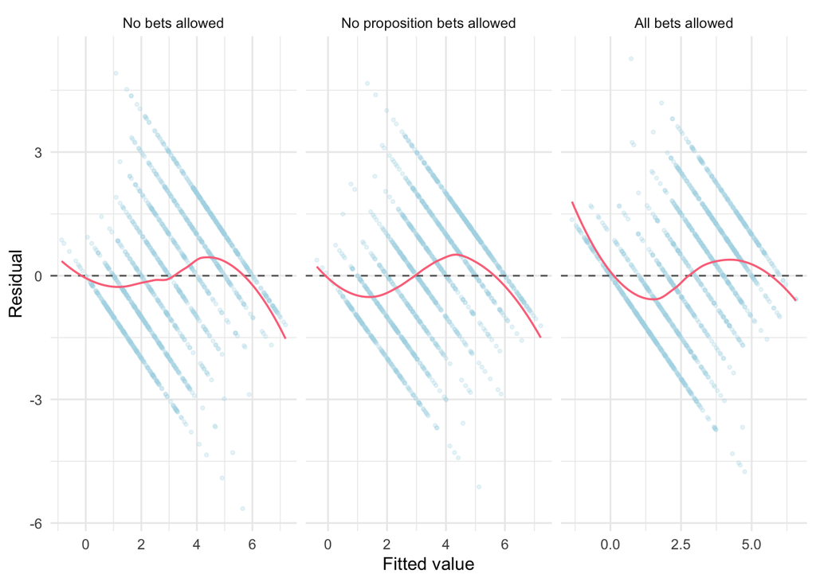

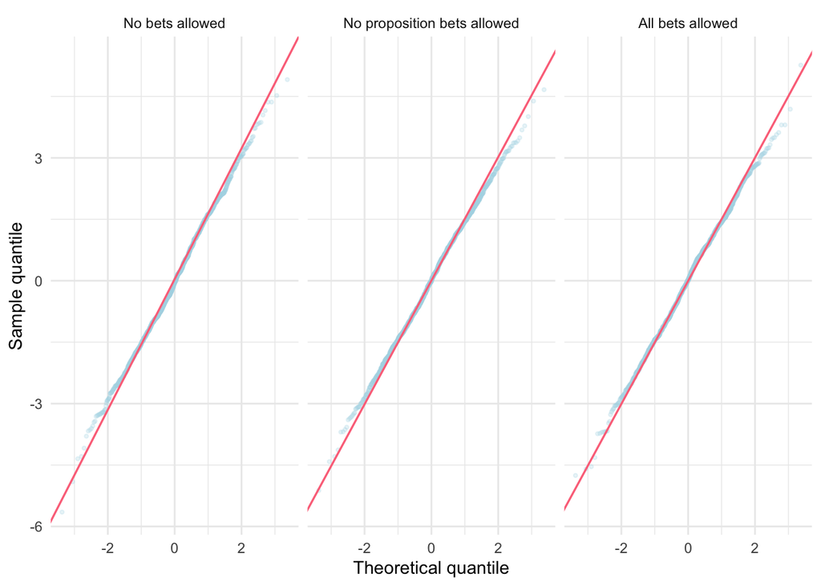

Linear mixed models assume residuals with constant variance and an approximately normal distribution, and normally distributed random intercepts. The residual plots should show no funnel shape or curvature, and the quantile plots should stay near the diagonal. Because responses are bounded integers from 0 to 6, mild banding in the residual plots is expected and is not by itself a problem.

Distribution of the participant random intercepts

| Model | InterceptSkew | InterceptKurtosis | InterceptShapiroP |
| --- | --- | --- | --- |
| No bets allowed | -0.273 | -0.177 | 0.016 |
| No proposition bets allowed | -0.331 | 0.065 | 0.016 |
| All bets allowed | 0.143 | 0.485 | 0.001 |

### Betting Statement Models (Table 6)

The three betting statements are measured once per participant, so these are ordinary regressions with no random effect. Predictors are the individual difference variables and the five responsibility statements. The betting statements appear as predictors in the bet allowance models above and as outcomes here, so the two sections answer different questions and should not be read as a single causal chain.

|  | Economic benefits |  |  | Negative consequences |  |  | Frequent advertisements |  |  |
| --- | --- | --- | --- | --- | --- | --- | --- | --- | --- |
| Predictors | Estimates | CI | p | Estimates | CI | p | Estimates | CI | p |
| (Intercept) | 0.28 | -0.26 – 0.82 | 0.306 | 3.55 | 3.01 – 4.08 | **<0.001** | 3.18 | 2.64 – 3.72 | **<0.001** |
| Age10 | -0.02 | -0.08 – 0.04 | 0.597 | 0.02 | -0.04 – 0.08 | 0.507 | 0.01 | -0.05 – 0.07 | 0.722 |
| Gender [Male] | -0.13 | -0.33 – 0.06 | 0.178 | 0.10 | -0.09 – 0.29 | 0.310 | 0.31 | 0.12 – 0.51 | **0.002** |
| EducationBinary [Bachelor's or Higher] | 0.12 | -0.09 – 0.33 | 0.258 | 0.19 | -0.01 – 0.40 | 0.065 | 0.29 | 0.08 – 0.50 | **0.006** |
| FinancialNum | -0.01 | -0.09 – 0.06 | 0.774 | -0.03 | -0.11 – 0.04 | 0.362 | -0.05 | -0.12 – 0.03 | 0.231 |
| RaceBinary | -0.05 | -0.23 – 0.14 | 0.633 | 0.07 | -0.11 – 0.26 | 0.448 | 0.12 | -0.07 – 0.30 | 0.226 |
| ATGS mean | 0.54 | 0.40 – 0.68 | **<0.001** | -0.82 | -0.96 – -0.68 | **<0.001** | -0.61 | -0.75 – -0.47 | **<0.001** |
| PeerPercent10 | -0.01 | -0.07 – 0.05 | 0.711 | 0.06 | 0.01 – 0.12 | **0.032** | 0.01 | -0.05 – 0.06 | 0.739 |
| PeerApproveNum | 0.14 | 0.07 – 0.22 | **<0.001** | -0.03 | -0.10 – 0.05 | 0.479 | -0.00 | -0.08 – 0.07 | 0.929 |
| PeerStruggle [Yes] | -0.05 | -0.33 – 0.24 | 0.757 | 0.04 | -0.25 – 0.32 | 0.802 | 0.15 | -0.13 – 0.44 | 0.296 |
| SelfStruggle [Yes] | -0.06 | -0.43 – 0.30 | 0.735 | -0.02 | -0.38 – 0.35 | 0.925 | -0.09 | -0.45 – 0.28 | 0.637 |
| FrequencyLog | 0.02 | -0.15 – 0.20 | 0.800 | -0.06 | -0.23 – 0.12 | 0.520 | 0.11 | -0.07 – 0.28 | 0.228 |
| TypicalBetLog | 0.01 | -0.07 – 0.09 | 0.795 | -0.06 | -0.13 – 0.02 | 0.137 | -0.05 | -0.13 – 0.03 | 0.188 |
| NumPlatformsLog | 0.15 | -0.13 – 0.43 | 0.301 | 0.24 | -0.04 – 0.52 | 0.098 | 0.11 | -0.17 – 0.40 | 0.429 |
| SportsEngagementProp | 0.39 | 0.00 – 0.79 | **0.049** | 0.40 | 0.01 – 0.79 | **0.044** | 0.12 | -0.27 – 0.51 | 0.547 |
| IndividualsBlame | 0.08 | -0.01 – 0.16 | 0.073 | -0.08 | -0.16 – -0.00 | **0.050** | -0.07 | -0.15 – 0.01 | 0.102 |
| SportsBettingCompaniesBlame | 0.01 | -0.10 – 0.13 | 0.819 | 0.01 | -0.10 – 0.12 | 0.898 | 0.13 | 0.02 – 0.24 | **0.025** |
| GovernmentBlame | 0.07 | -0.03 – 0.18 | 0.182 | 0.15 | 0.05 – 0.26 | **0.004** | 0.08 | -0.02 – 0.19 | 0.123 |
| SportsOrganizationsBlame | 0.10 | -0.01 – 0.20 | 0.066 | -0.03 | -0.13 – 0.08 | 0.626 | -0.09 | -0.20 – 0.01 | 0.075 |
| MediaBlame | -0.13 | -0.23 – -0.02 | **0.018** | 0.04 | -0.06 – 0.14 | 0.457 | 0.10 | 0.00 – 0.21 | **0.050** |
| Observations | 445 |  |  | 445 |  |  | 445 |  |  |
| R<sup>2</sup> / R<sup>2</sup> adjusted | 0.382 / 0.355 |  |  | 0.449 / 0.425 |  |  | 0.363 / 0.335 |  |  |

Joint F tests for the three betting activity measures

| Model | F | df1 | df2 | p | DeltaR2 |
| --- | --- | --- | --- | --- | --- |
| Economic benefits | 0.931 | 3 | 425 | 0.426 | 0.004 |
| Negative consequences | 1.103 | 3 | 425 | 0.347 | 0.004 |
| Frequent advertisements | 1.518 | 3 | 425 | 0.209 | 0.007 |

#### Model Fit and Assumptions

Fit, multicollinearity, and assumption checks for the betting statement models

| Model | N | F | df1 | df2 | R2 | AdjR2 | ModelP | MaxVIF | BreuschPaganP | ResidualSkew | ResidualKurtosis | MaxCooksD | Influential |
| --- | --- | --- | --- | --- | --- | --- | --- | --- | --- | --- | --- | --- | --- |
| Economic benefits | 445 | 13.847 | 19 | 425 | 0.382 | 0.355 | 0 | 2.976 | 0.203 | -0.257 | 0.419 | 0.036 | 28 |
| Negative consequences | 445 | 18.242 | 19 | 425 | 0.449 | 0.425 | 0 | 2.976 | 0.000 | -0.289 | -0.271 | 0.020 | 27 |
| Frequent advertisements | 445 | 12.764 | 19 | 425 | 0.363 | 0.335 | 0 | 2.976 | 0.000 | -0.586 | 0.173 | 0.027 | 22 |

Note. BreuschPaganP below .05 indicates non-constant residual variance. Influential counts cases with Cook's D above 4/n; values of Cook's D above 1 are the conventional concern.

#### Multicollinearity

Variance inflation factors for the betting statement models

| Term | Economic benefits | Negative consequences | Frequent advertisements |
| --- | --- | --- | --- |
| Age10 | 1.11 | 1.11 | 1.11 |
| Gender | 1.16 | 1.16 | 1.16 |
| EducationBinary | 1.23 | 1.23 | 1.23 |
| FinancialNum | 1.23 | 1.23 | 1.23 |
| RaceBinary | 1.07 | 1.07 | 1.07 |
| ATGS_mean | 1.91 | 1.91 | 1.91 |
| PeerPercent10 | 1.86 | 1.86 | 1.86 |
| PeerApproveNum | 1.93 | 1.93 | 1.93 |
| PeerStruggle | 1.64 | 1.64 | 1.64 |
| SelfStruggle | 1.52 | 1.52 | 1.52 |
| FrequencyLog | 1.86 | 1.86 | 1.86 |
| TypicalBetLog | 2.03 | 2.03 | 2.03 |
| NumPlatformsLog | 2.98 | 2.98 | 2.98 |
| SportsEngagementProp | 1.62 | 1.62 | 1.62 |
| IndividualsBlame | 1.07 | 1.07 | 1.07 |
| SportsBettingCompaniesBlame | 1.91 | 1.91 | 1.91 |
| GovernmentBlame | 2.10 | 2.10 | 2.10 |
| SportsOrganizationsBlame | 2.04 | 2.04 | 2.04 |
| MediaBlame | 2.21 | 2.21 | 2.21 |

Note. Values are VIFs. Terms with more than one degree of freedom are reported as GVIF^(1/(2*Df)) squared so they are on the same scale. Values above 5 warrant attention and values above 10 indicate serious multicollinearity.

#### Residual Diagnostics

Residual distribution for the betting statement models

| Model | ResidualSD | Skew | Kurtosis | ShapiroP |
| --- | --- | --- | --- | --- |
| Economic benefits | 0.953 | -0.257 | 0.419 | 0.054 |
| Negative consequences | 0.941 | -0.289 | -0.271 | 0.004 |
| Frequent advertisements | 0.950 | -0.586 | 0.173 | 0.000 |

Note. Shapiro-Wilk is oversensitive at this sample size, so the quantile plots below are the more informative check. Skew and kurtosis within about plus or minus 1 are unproblematic for regression.

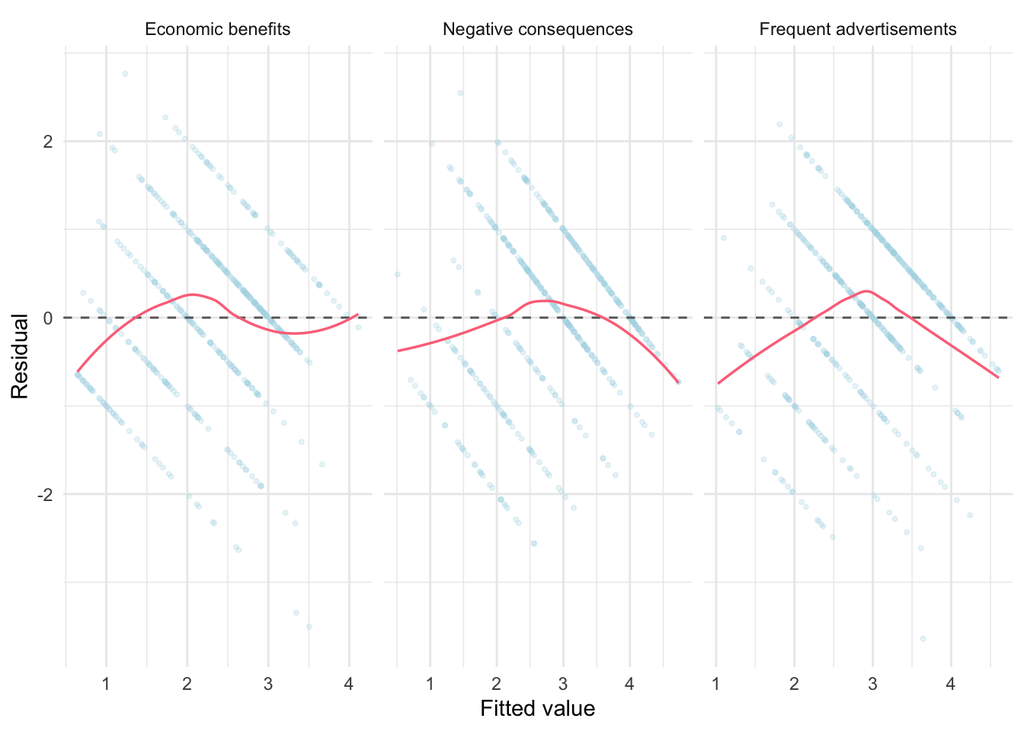

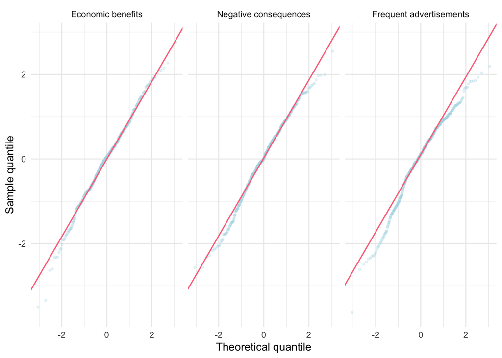

Terms whose significance changes with HC3 robust standard errors

| Model | Term | b | pOLS | pHC3 |
| --- | --- | --- | --- | --- |
| Economic benefits | SportsEngagementProp | 0.394 | 0.049 | 0.055 |
| Negative consequences | SportsEngagementProp | 0.398 | 0.044 | 0.050 |
| Negative consequences | IndividualsBlame | -0.082 | 0.050 | 0.060 |
| Frequent advertisements | MediaBlame | 0.104 | 0.050 | 0.067 |

These outcomes are integers bounded between 0 and 4, so residuals will fall on discrete bands and the tails of the quantile plots will deviate from the diagonal. Ordinary regression is robust to that at this sample size. The Breusch-Pagan test is the check that matters more here: a significant result means the residual variance is not constant, which leaves the coefficients unbiased but makes the standard errors, confidence intervals, and p values unreliable. Heteroscedasticity-robust (HC3) standard errors are the usual remedy and can be added with the sandwich and lmtest packages.

### Comparing Responsibility Across Groups

The five responsibility ratings are repeated measures, so a one-way repeated measures ANOVA tests whether mean responsibility differs across groups. Mauchly’s test checks sphericity and the Greenhouse-Geisser correction is applied when it is violated. Follow-up paired t tests compare every pair of groups with Holm-adjusted p values, and Cohen’s dz (mean difference divided by the standard deviation of the differences) gives the effect size for each pair.

Repeated measures ANOVA on responsibility ratings (Greenhouse-Geisser corrected)

| Effect | num Df | den Df | MSE | F | pes | ges | Pr(>F) |
| --- | --- | --- | --- | --- | --- | --- | --- |
| Group | 3.119 | 1384.752 | 1.165 | 46.662 | 0.095 | 0.049 | 0 |

Sphericity corrections

| Effect | GG eps | Pr(>F[GG]) | HF eps | Pr(>F[HF]) |
| --- | --- | --- | --- | --- |
| Group | 0.78 | 0 | 0.786 | 0 |

Mauchly's test of sphericity

| Effect | Test statistic | p-value |
| --- | --- | --- |
| Group | 0.62 | 0 |

Pairwise comparisons of responsibility ratings (paired t tests, Holm adjusted)

| GroupA | GroupB | MeanA | MeanB | MeanDiff | CILow | CIHigh | t | df | p | dz | pHolm |
| --- | --- | --- | --- | --- | --- | --- | --- | --- | --- | --- | --- |
| Betting companies | Media platforms | 2.849 | 2.036 | 0.813 | 0.705 | 0.922 | 14.768 | 444 | 0.000 | 0.700 | 0.000 |
| Betting companies | Sports organizations | 2.849 | 2.279 | 0.571 | 0.461 | 0.680 | 10.247 | 444 | 0.000 | 0.486 | 0.000 |
| Individual bettors | Media platforms | 2.589 | 2.036 | 0.553 | 0.399 | 0.707 | 7.047 | 444 | 0.000 | 0.334 | 0.000 |
| Government regulators | Media platforms | 2.488 | 2.036 | 0.452 | 0.344 | 0.560 | 8.223 | 444 | 0.000 | 0.390 | 0.000 |
| Betting companies | Government regulators | 2.849 | 2.488 | 0.362 | 0.264 | 0.460 | 7.274 | 444 | 0.000 | 0.345 | 0.000 |
| Individual bettors | Sports organizations | 2.589 | 2.279 | 0.310 | 0.160 | 0.461 | 4.052 | 444 | 0.000 | 0.192 | 0.000 |
| Individual bettors | Betting companies | 2.589 | 2.849 | -0.261 | -0.401 | -0.120 | -3.643 | 444 | 0.000 | -0.173 | 0.001 |
| Sports organizations | Media platforms | 2.279 | 2.036 | 0.243 | 0.142 | 0.343 | 4.750 | 444 | 0.000 | 0.225 | 0.000 |
| Government regulators | Sports organizations | 2.488 | 2.279 | 0.209 | 0.098 | 0.320 | 3.714 | 444 | 0.000 | 0.176 | 0.001 |
| Individual bettors | Government regulators | 2.589 | 2.488 | 0.101 | -0.055 | 0.257 | 1.275 | 444 | 0.203 | 0.060 | 0.203 |

Note. MeanDiff is Group A minus Group B. dz is the mean difference divided by the SD of the paired differences. pHolm is adjusted across all 10 comparisons.

### Responsibility Models (Table 7)

The five responsibility statements are predicted from the individual difference variables only. No responsibility rating is used to predict another, and the betting statements are excluded so these models stay a clean test of who attributes responsibility to each group.

|  | Individual bettors |  |  | Betting companies |  |  | Government regulators |  |  | Sports organizations |  |  | Media platforms |  |  |
| --- | --- | --- | --- | --- | --- | --- | --- | --- | --- | --- | --- | --- | --- | --- | --- |
| Predictors | Estimates | CI | p | Estimates | CI | p | Estimates | CI | p | Estimates | CI | p | Estimates | CI | p |
| (Intercept) | 2.03 | 1.55 – 2.50 | **<0.001** | 3.55 | 3.11 – 3.99 | **<0.001** | 2.87 | 2.40 – 3.34 | **<0.001** | 2.23 | 1.74 – 2.71 | **<0.001** | 2.50 | 2.01 – 2.99 | **<0.001** |
| Age10 | 0.03 | -0.04 – 0.10 | 0.389 | -0.03 | -0.10 – 0.03 | 0.301 | 0.02 | -0.05 – 0.09 | 0.637 | 0.07 | -0.00 – 0.14 | 0.055 | -0.01 | -0.08 – 0.06 | 0.774 |
| Gender [Male] | 0.15 | -0.07 – 0.37 | 0.182 | 0.10 | -0.11 – 0.30 | 0.365 | 0.13 | -0.09 – 0.36 | 0.230 | 0.37 | 0.14 – 0.60 | **0.001** | 0.17 | -0.06 – 0.40 | 0.145 |
| EducationBinary [Bachelor's or Higher] | -0.11 | -0.34 – 0.13 | 0.380 | 0.32 | 0.10 – 0.54 | **0.004** | 0.37 | 0.14 – 0.61 | **0.002** | 0.36 | 0.12 – 0.61 | **0.004** | 0.35 | 0.11 – 0.60 | **0.005** |
| FinancialNum | 0.10 | 0.02 – 0.19 | **0.019** | -0.04 | -0.11 – 0.04 | 0.379 | -0.03 | -0.12 – 0.05 | 0.427 | -0.07 | -0.16 – 0.02 | 0.109 | -0.04 | -0.12 – 0.05 | 0.412 |
| RaceBinary | -0.15 | -0.37 – 0.07 | 0.173 | 0.00 | -0.20 – 0.20 | 0.997 | -0.19 | -0.41 – 0.02 | 0.074 | -0.05 | -0.27 – 0.17 | 0.657 | -0.04 | -0.26 – 0.18 | 0.718 |
| ATGS mean | 0.02 | -0.13 – 0.17 | 0.790 | -0.42 | -0.56 – -0.28 | **<0.001** | -0.58 | -0.73 – -0.43 | **<0.001** | -0.43 | -0.59 – -0.28 | **<0.001** | -0.47 | -0.62 – -0.31 | **<0.001** |
| PeerPercent10 | 0.01 | -0.05 – 0.07 | 0.748 | 0.00 | -0.05 – 0.06 | 0.899 | 0.02 | -0.04 – 0.08 | 0.505 | 0.01 | -0.06 – 0.07 | 0.862 | 0.11 | 0.05 – 0.18 | **0.001** |
| PeerApproveNum | -0.01 | -0.10 – 0.08 | 0.817 | -0.06 | -0.14 – 0.02 | 0.168 | -0.00 | -0.09 – 0.08 | 0.924 | -0.02 | -0.11 – 0.07 | 0.621 | -0.10 | -0.19 – -0.01 | **0.025** |
| PeerStruggle [Yes] | 0.24 | -0.08 – 0.57 | 0.143 | -0.01 | -0.31 – 0.29 | 0.952 | 0.12 | -0.20 – 0.44 | 0.458 | 0.50 | 0.16 – 0.83 | **0.004** | 0.27 | -0.06 – 0.61 | 0.110 |
| SelfStruggle [Yes] | -0.05 | -0.47 – 0.38 | 0.828 | 0.09 | -0.30 – 0.48 | 0.651 | 0.20 | -0.22 – 0.62 | 0.350 | -0.04 | -0.47 – 0.40 | 0.870 | 0.26 | -0.18 – 0.70 | 0.241 |
| FrequencyLog | -0.05 | -0.25 – 0.15 | 0.603 | -0.05 | -0.23 – 0.14 | 0.630 | 0.03 | -0.17 – 0.23 | 0.742 | 0.01 | -0.19 – 0.22 | 0.892 | -0.08 | -0.29 – 0.12 | 0.434 |
| TypicalBetLog | -0.02 | -0.11 – 0.07 | 0.634 | -0.00 | -0.09 – 0.08 | 0.909 | 0.02 | -0.06 – 0.11 | 0.583 | 0.01 | -0.08 – 0.10 | 0.832 | -0.02 | -0.11 – 0.07 | 0.626 |
| NumPlatformsLog | 0.17 | -0.15 – 0.50 | 0.301 | 0.25 | -0.05 – 0.55 | 0.108 | -0.03 | -0.36 – 0.29 | 0.832 | 0.08 | -0.25 – 0.42 | 0.625 | 0.26 | -0.08 – 0.60 | 0.129 |
| SportsEngagementProp | 0.06 | -0.39 – 0.51 | 0.796 | 0.19 | -0.23 – 0.61 | 0.368 | 0.62 | 0.18 – 1.07 | **0.006** | 0.42 | -0.05 – 0.88 | 0.078 | 0.27 | -0.20 – 0.73 | 0.257 |
| Observations | 445 |  |  | 445 |  |  | 445 |  |  | 445 |  |  | 445 |  |  |
| R<sup>2</sup> / R<sup>2</sup> adjusted | 0.042 / 0.011 |  |  | 0.158 / 0.131 |  |  | 0.222 / 0.196 |  |  | 0.179 / 0.152 |  |  | 0.214 / 0.189 |  |  |

#### Model Fit and Assumptions

Fit, multicollinearity, and assumption checks for the responsibility models

| Model | N | F | df1 | df2 | R2 | AdjR2 | ModelP | MaxVIF | BreuschPaganP | ResidualSkew | ResidualKurtosis | MaxCooksD | Influential |
| --- | --- | --- | --- | --- | --- | --- | --- | --- | --- | --- | --- | --- | --- |
| Individual bettors | 445 | 1.343 | 14 | 430 | 0.042 | 0.011 | 0.178 | 2.929 | 0.471 | -0.505 | -0.508 | 0.036 | 18 |
| Betting companies | 445 | 5.771 | 14 | 430 | 0.158 | 0.131 | 0.000 | 2.929 | 0.000 | -0.903 | 0.697 | 0.077 | 25 |
| Government regulators | 445 | 8.748 | 14 | 430 | 0.222 | 0.196 | 0.000 | 2.929 | 0.007 | -0.408 | -0.282 | 0.024 | 24 |
| Sports organizations | 445 | 6.676 | 14 | 430 | 0.179 | 0.152 | 0.000 | 2.929 | 0.001 | -0.146 | -0.692 | 0.022 | 16 |
| Media platforms | 445 | 8.371 | 14 | 430 | 0.214 | 0.189 | 0.000 | 2.929 | 0.178 | 0.016 | -0.584 | 0.042 | 25 |

Note. BreuschPaganP below .05 indicates non-constant residual variance. Influential counts cases with Cook's D above 4/n; values of Cook's D above 1 are the conventional concern.

#### Multicollinearity

Variance inflation factors for the responsibility models

| Term | Individual bettors | Betting companies | Government regulators | Sports organizations | Media platforms |
| --- | --- | --- | --- | --- | --- |
| Age10 | 1.09 | 1.09 | 1.09 | 1.09 | 1.09 |
| Gender | 1.13 | 1.13 | 1.13 | 1.13 | 1.13 |
| EducationBinary | 1.19 | 1.19 | 1.19 | 1.19 | 1.19 |
| FinancialNum | 1.20 | 1.20 | 1.20 | 1.20 | 1.20 |
| RaceBinary | 1.05 | 1.05 | 1.05 | 1.05 | 1.05 |
| ATGS_mean | 1.65 | 1.65 | 1.65 | 1.65 | 1.65 |
| PeerPercent10 | 1.78 | 1.78 | 1.78 | 1.78 | 1.78 |
| PeerApproveNum | 1.89 | 1.89 | 1.89 | 1.89 | 1.89 |
| PeerStruggle | 1.60 | 1.60 | 1.60 | 1.60 | 1.60 |
| SelfStruggle | 1.51 | 1.51 | 1.51 | 1.51 | 1.51 |
| FrequencyLog | 1.85 | 1.85 | 1.85 | 1.85 | 1.85 |
| TypicalBetLog | 2.02 | 2.02 | 2.02 | 2.02 | 2.02 |
| NumPlatformsLog | 2.93 | 2.93 | 2.93 | 2.93 | 2.93 |
| SportsEngagementProp | 1.59 | 1.59 | 1.59 | 1.59 | 1.59 |

Note. Values are VIFs. Terms with more than one degree of freedom are reported as GVIF^(1/(2*Df)) squared so they are on the same scale. Values above 5 warrant attention and values above 10 indicate serious multicollinearity.

#### Residual Diagnostics

Residual distribution for the responsibility models

| Model | ResidualSD | Skew | Kurtosis | ShapiroP |
| --- | --- | --- | --- | --- |
| Individual bettors | 1.109 | -0.505 | -0.508 | 0.000 |
| Betting companies | 1.028 | -0.903 | 0.697 | 0.000 |
| Government regulators | 1.098 | -0.408 | -0.282 | 0.000 |
| Sports organizations | 1.141 | -0.146 | -0.692 | 0.001 |
| Media platforms | 1.146 | 0.016 | -0.584 | 0.027 |

Note. Shapiro-Wilk is oversensitive at this sample size, so the quantile plots below are the more informative check. Skew and kurtosis within about plus or minus 1 are unproblematic for regression.

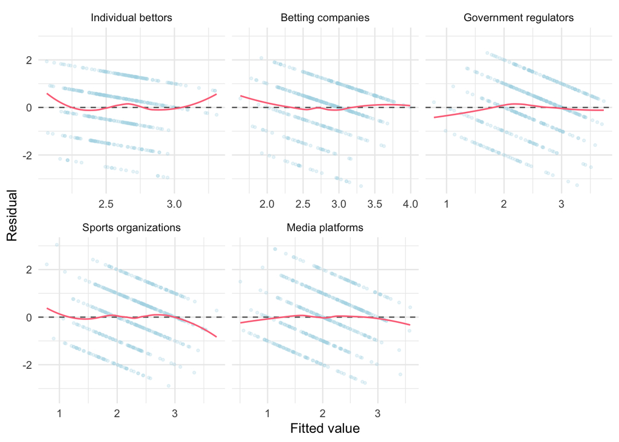

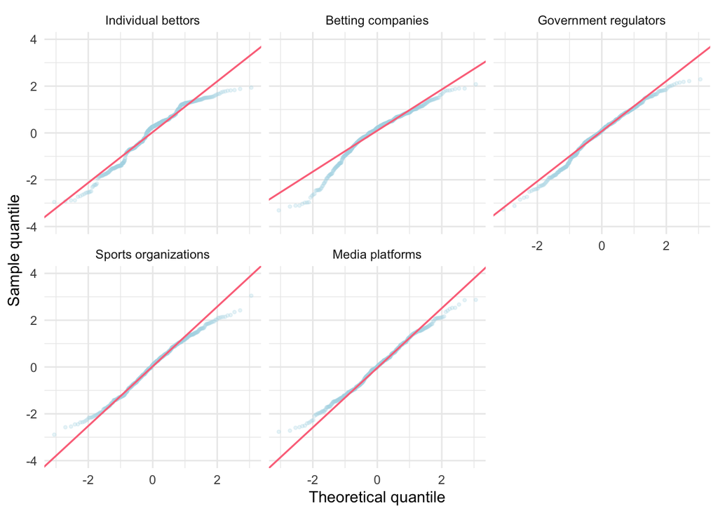

Terms whose significance changes with HC3 robust standard errors

| Model | Term | b | pOLS | pHC3 |
| --- | --- | --- | --- | --- |

### Values Cited in the Text

Highest variance inflation factor across all models

| HighestVIF |
| --- |
| 3 |

Agreement that sports betting advertisements are too frequent, by betting history

| EverBet | n | AgreeAdsTooFrequent |
| --- | --- | --- |
| Has bet | 336 | 68.8 |
| Never bet | 109 | 71.6 |